# Fitting Exercise

# Load and summarize data

```r
library(dplyr)
library(ggplot2)
library(readr)
library(GGally)
library(tidymodels)
mavo <- read_csv("Mavoglurant.csv")
glimpse(mavo)
```

```
Rows: 2,678
Columns: 17
$ ID   <dbl> 793, 793, 793, 793, 793, 793, 793, 793, 793, 793, 793, 793, 793, …
$ CMT  <dbl> 1, 2, 2, 2, 2, 2, 2, 2, 2, 2, 2, 2, 2, 2, 2, 2, 1, 2, 2, 2, 2, 2,…
$ EVID <dbl> 1, 0, 0, 0, 0, 0, 0, 0, 0, 0, 0, 0, 0, 0, 0, 0, 1, 0, 0, 0, 0, 0,…
$ EVI2 <dbl> 1, 0, 0, 0, 0, 0, 0, 0, 0, 0, 0, 0, 0, 0, 0, 0, 1, 0, 0, 0, 0, 0,…
$ MDV  <dbl> 1, 0, 0, 0, 0, 0, 0, 0, 0, 0, 0, 0, 0, 0, 0, 0, 1, 0, 0, 0, 0, 0,…
$ DV   <dbl> 0.00, 491.00, 605.00, 556.00, 310.00, 237.00, 147.00, 101.00, 72.…
$ LNDV <dbl> 0.000, 6.196, 6.405, 6.321, 5.737, 5.468, 4.990, 4.615, 4.282, 3.…
$ AMT  <dbl> 25, 0, 0, 0, 0, 0, 0, 0, 0, 0, 0, 0, 0, 0, 0, 0, 25, 0, 0, 0, 0, …
$ TIME <dbl> 0.000, 0.200, 0.250, 0.367, 0.533, 0.700, 1.200, 2.200, 3.200, 4.…
$ DOSE <dbl> 25, 25, 25, 25, 25, 25, 25, 25, 25, 25, 25, 25, 25, 25, 25, 25, 2…
$ OCC  <dbl> 1, 1, 1, 1, 1, 1, 1, 1, 1, 1, 1, 1, 1, 1, 1, 1, 1, 1, 1, 1, 1, 1,…
$ RATE <dbl> 75, 0, 0, 0, 0, 0, 0, 0, 0, 0, 0, 0, 0, 0, 0, 0, 150, 0, 0, 0, 0,…
$ AGE  <dbl> 42, 42, 42, 42, 42, 42, 42, 42, 42, 42, 42, 42, 42, 42, 42, 42, 2…
$ SEX  <dbl> 1, 1, 1, 1, 1, 1, 1, 1, 1, 1, 1, 1, 1, 1, 1, 1, 1, 1, 1, 1, 1, 1,…
$ RACE <dbl> 2, 2, 2, 2, 2, 2, 2, 2, 2, 2, 2, 2, 2, 2, 2, 2, 2, 2, 2, 2, 2, 2,…
$ WT   <dbl> 94.3, 94.3, 94.3, 94.3, 94.3, 94.3, 94.3, 94.3, 94.3, 94.3, 94.3,…
$ HT   <dbl> 1.769997, 1.769997, 1.769997, 1.769997, 1.769997, 1.769997, 1.769…
```

```r
dim(mavo)
```

```
[1] 2678   17
```

# Convert data to plot

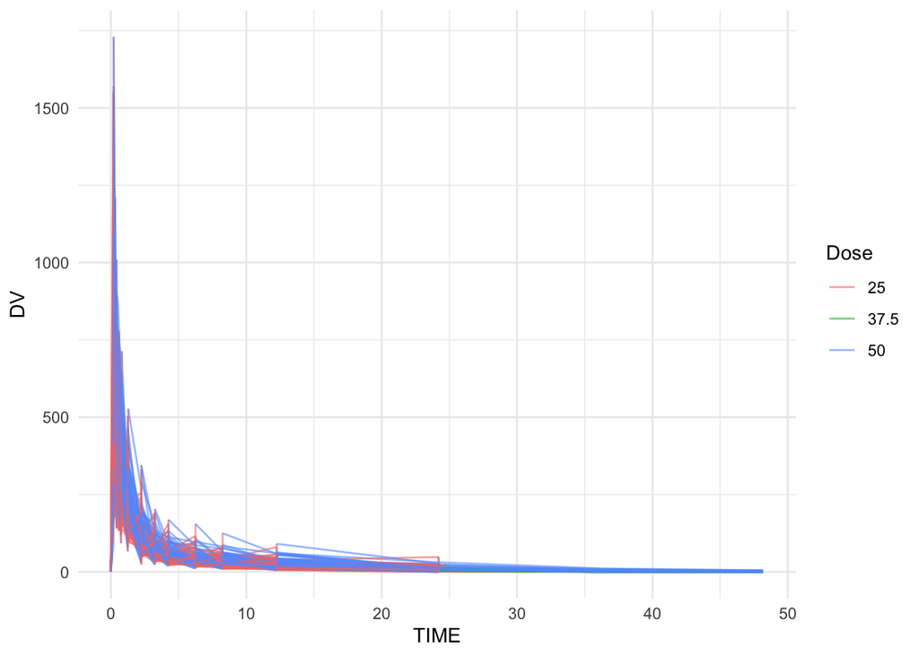

```r
ggplot(mavo, aes(x = TIME, y = DV, group = ID, color = factor(DOSE))) +
  geom_line(alpha = 0.6) +
  labs(color = "Dose") +
  theme_minimal()
```

```r
#only keeping observations with OCC = 1
mavo_occ1 <- mavo %>%
  filter(OCC == 1)

table(mavo_occ1$OCC)
```

```
   1
1665
```

# Creates a data frame with time that is not equal to 0 and computes the sum of DV

```r
mavo_no0 <- mavo_occ1 %>%
  filter(TIME != 0)

Y_df <- mavo_no0 %>%
  group_by(ID) %>%
  summarize(Y = sum(DV, na.rm = TRUE))
```

# Creates a data frame with time = 0

```r
baseline_df <- mavo_occ1 %>%
  filter(TIME == 0)
```

# Joins the tow data frames together

```r
final_df <- baseline_df %>%
  left_join(Y_df, by = "ID")

dim(final_df)
```

```
[1] 120  18
```

# Coverts race and sex to variable factors and cleans data

```r
clean_df <- final_df %>%
  mutate(
    SEX = factor(SEX),
    RACE = factor(RACE)
  ) %>%
  select(Y, DOSE, AGE, SEX, RACE, WT, HT)

saveRDS(clean_df, file = "clean-data.rds")

summary(clean_df)
```

```
       Y               DOSE            AGE        SEX     RACE
 Min.   : 826.4   Min.   :25.00   Min.   :18.00   1:104   1 :74
 1st Qu.:1700.5   1st Qu.:25.00   1st Qu.:26.00   2: 16   2 :36
 Median :2349.1   Median :37.50   Median :31.00           7 : 2
 Mean   :2445.4   Mean   :36.46   Mean   :33.00           88: 8
 3rd Qu.:3050.2   3rd Qu.:50.00   3rd Qu.:40.25
 Max.   :5606.6   Max.   :50.00   Max.   :50.00
       WT               HT
 Min.   : 56.60   Min.   :1.520
 1st Qu.: 73.17   1st Qu.:1.700
 Median : 82.10   Median :1.770
 Mean   : 82.55   Mean   :1.759
 3rd Qu.: 90.10   3rd Qu.:1.813
 Max.   :115.30   Max.   :1.930
```

# Summary of data

```r
clean_df %>%
  summarize(
    n = n(),
    mean_Y = mean(Y),
    sd_Y = sd(Y),
    mean_age = mean(AGE),
    mean_WT = mean(WT),
    mean_HT = mean(HT)
  )
```

```
# A tibble: 1 × 6
      n mean_Y  sd_Y mean_age mean_WT mean_HT
  <int>  <dbl> <dbl>    <dbl>   <dbl>   <dbl>
1   120  2445.  962.       33    82.6    1.76
```

This summary table shows that there are 120 indivduals and it shows the the mean and standard deviation of drug exposure, and the mean od age, WT, and HT.

# Summary grouped by dose

```r
  clean_df %>%
  group_by(DOSE) %>%
  summarize(
    n = n(),
    mean_Y = mean(Y),
    sd_Y = sd(Y),
    mean_WT = mean(WT),
    mean_AGE = mean(AGE)
  )
```

```
# A tibble: 3 × 6
   DOSE     n mean_Y  sd_Y mean_WT mean_AGE
  <dbl> <int>  <dbl> <dbl>   <dbl>    <dbl>
1  25      59  1783.  601.    81.5     32.1
2  37.5    12  2464.  488.    81.1     36.1
3  50      49  3239.  787.    84.2     33.4
```

# Summary grouped by sex

```r
  clean_df %>%
  group_by(SEX) %>%
  summarize(
    n = n(),
    mean_Y = mean(Y),
    mean_WT = mean(WT)
  )
```

```
# A tibble: 2 × 4
  SEX       n mean_Y mean_WT
  <fct> <int>  <dbl>   <dbl>
1 1       104  2478.    84.1
2 2        16  2236.    72.5
```

This summary table shows the data grouped by sex. Sex 1 has 104 individuals and sex 2 has 16 individuals.

# Plot y versus dose

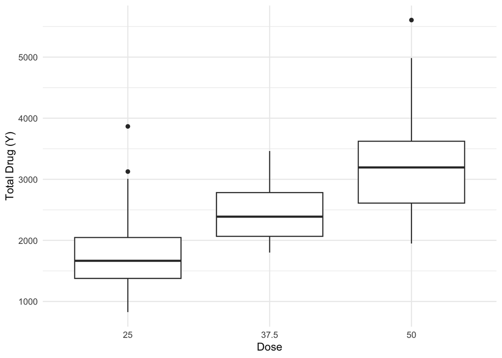

```r
ggplot(clean_df, aes(x = factor(DOSE), y = Y)) +
  geom_boxplot() +
  labs(x = "Dose", y = "Total Drug (Y)") +
  theme_minimal()
```

This boxplot shows total drug exposure versus dose; the higher the dose is associated with drug exposure.

# Plot y versus age

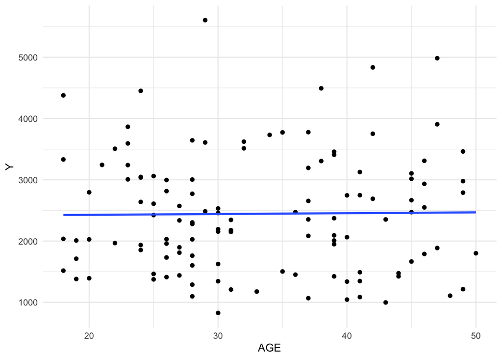

```r
  ggplot(clean_df, aes(x = AGE, y = Y)) +
  geom_point() +
  geom_smooth(method = "lm", se = FALSE) +
  theme_minimal()
```

This scatterplot shows total drug exposure versus age; there is no relationship between the two variables.

# Distribution of Y

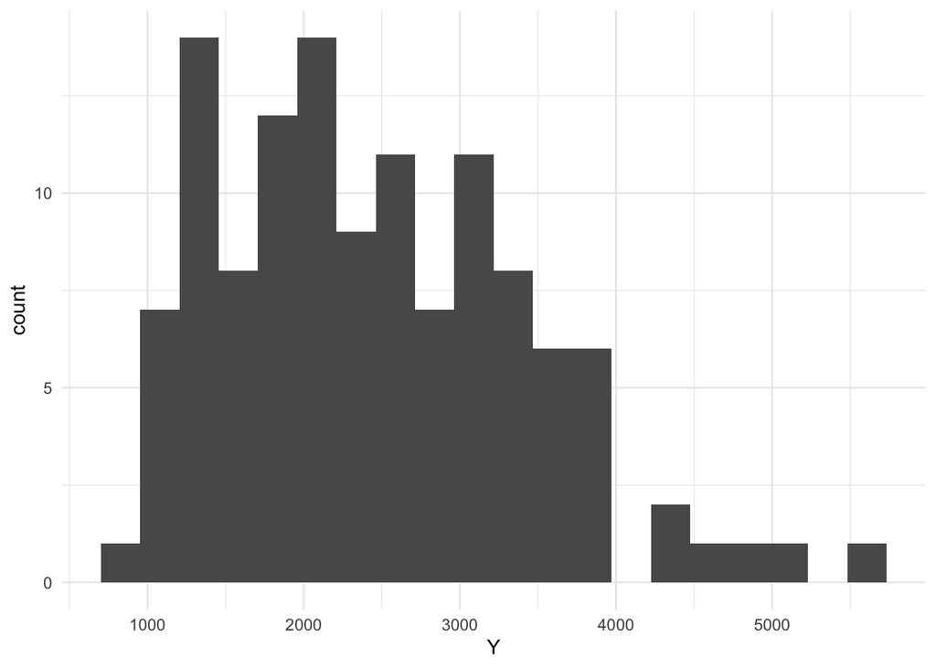

```r
ggplot(clean_df, aes(x = Y)) +
  geom_histogram(bins = 20) +
  theme_minimal()
```

This histogram shows total drug exposure skewed to the right. This means that most individuals have exposure values between 1500 and 3500, but a few individuals have high exposure values.

# Distribution of HT

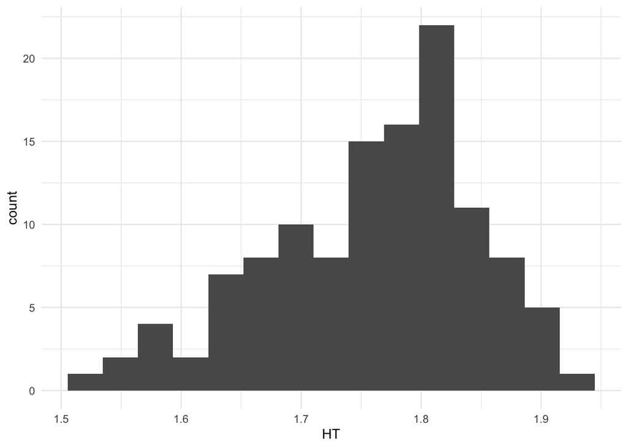

```r
  ggplot(clean_df, aes(x = HT)) +
  geom_histogram(bins = 15) +
  theme_minimal()
```

The histogram shoes height with a normal distribution with most idividuals within 1.60 to 1.90 meters.

# Correlation matrix

```r
numeric_df <- clean_df %>%
  select(Y, AGE, WT, HT)

cor(numeric_df)
```

```
              Y         AGE         WT         HT
Y    1.00000000  0.01256372 -0.2128719 -0.1583297
AGE  0.01256372  1.00000000  0.1196740 -0.3518581
WT  -0.21287194  0.11967399  1.0000000  0.5997505
HT  -0.15832972 -0.35185806  0.5997505  1.0000000
```

This correlation matrix shows the strength and whether the relationship is positive or negative between total drug exposure, age, height, and weight. +1 menas there is a positive relationship, 0 means there is no relationship, and -1 means there is a negative relationship.

# Correlation matrix plot plot

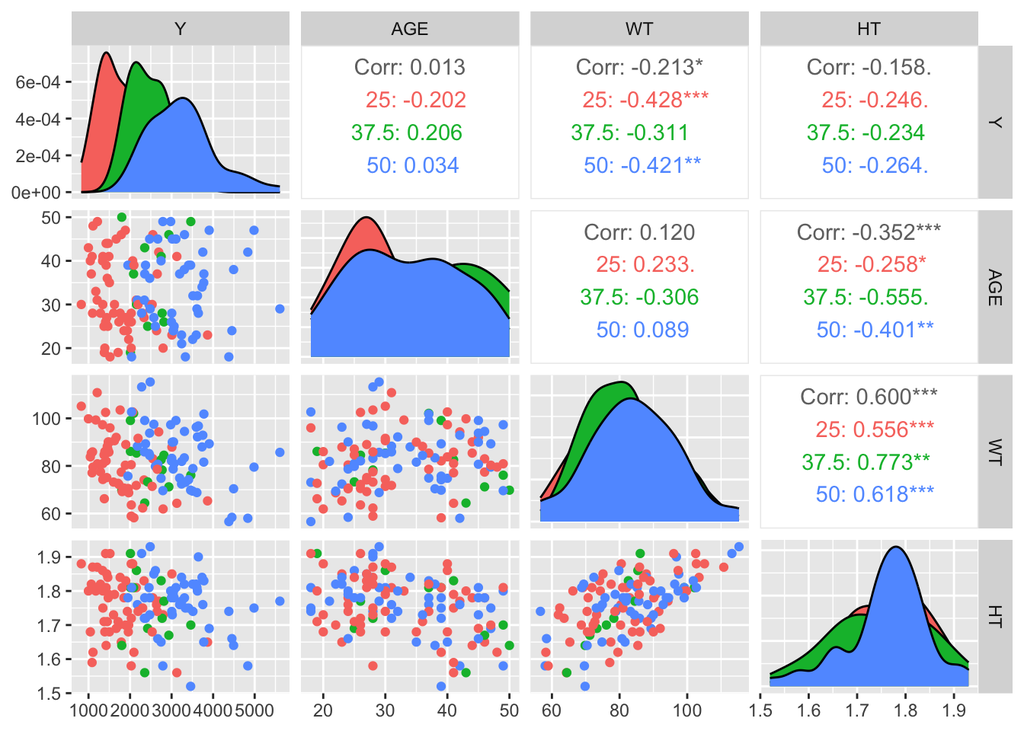

```r
ggpairs(clean_df,
        columns = c("Y", "AGE", "WT", "HT"),
        aes(color = factor(DOSE)))
```

This correlation matrix plot shows the same relationships as the correlation matrix table.